# Maps of collected biodiversity by Colombian institutions

In a previous [post](http://rpubs.com/dlizcano/6337) I got the georeferenced data set of biodiversity from [SIB](http://data.sibcolombia.net/conjuntos/) Colombia using [IAvH code](http://code.google.com/p/descarga-valida-gbif-sib/). The data set is composet of 127 tables corresponding to the [GBIF](http://www.gbif.org/) grid.

Some tables still need some additional work to fix extra spaces and inconsistent characters. But after some work, I put together all the tables. When plotting the data, you can see where Colombian researchers have mostly collected biodiversity.

This time I want to see the use of ggplot2 and ggmaps to discover the contribution of each institution.

## code chunks

The data set is 70 megas aprox.

```r
require(ggmap)
require(raster)
```

```r
#### load data set 252.944 records
bigtable <- read.csv(file = "data/sib_bigtable.csv", header = T)

# get poligon Colombia
co <- getData("GADM", country = "CO", level = 1, download = TRUE)
col_depto <- fortify(co, region = "NAME_1")  # make compatible to ggplot2
```

```
rgeos version: 0.2-17, (SVN revision 392) GEOS runtime version:
3.3.6-CAPI-1.7.6 Polygon checking: TRUE
```

```r
locat = as.vector(bbox(co))
ncmap = get_map(location = locat, source = "stamen", maptype = "toner", zoom = 6)
# ggmap(ncmap) not nice

mapbase <- ggplot(col_depto, aes(long, lat, group = group)) + geom_polygon(fill = "grey60") +
    coord_equal() + geom_path(color = "grey")

mapbase2 <- ggplot(col_depto, aes(long, lat, group = group)) + geom_polygon(fill = "White ") +
    coord_equal() + geom_path(color = "grey")

map1 <- mapbase2 + geom_point(aes(x = lon, y = lat, group = TRUE), data = bigtable,
    size = 1.5, alpha = 1/20) + theme(legend.position = "right") + guides(guide_legend((title = NULL)))

map2 <- mapbase + geom_point(aes(x = lon, y = lat, group = FALSE), size = 1,
    data = bigtable, alpha = I(0.25), colour = "steelblue") + stat_binhex(aes(x = lon,
    y = lat, group = FALSE), size = 0.5, binwidth = c(0.5, 0.5), alpha = 2/4,
    data = bigtable)

map3 <- mapbase + geom_point(aes(x = lon, y = lat, group = TRUE, colour = factor(institution)),
    data = bigtable, size = 2, alpha = 1/2) + theme(legend.position = "right")

map4 <- mapbase + geom_point(aes(x = lon, y = lat, group = FALSE), size = 0.5,
    data = bigtable, colour = "red") + facet_wrap(~institution, ncol = 6)
```

## The first map. All

A map showing all collection points. The points are transparent. So darker means more points in that location.

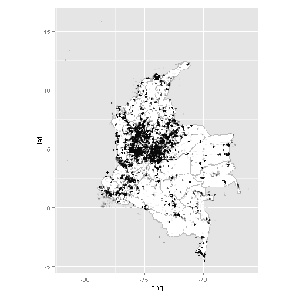

```r
map1
```

## The second map. Collected Where?

A map showing hexagonal bins with more collection points. Interesting: no hexagons means no colecction in that place.

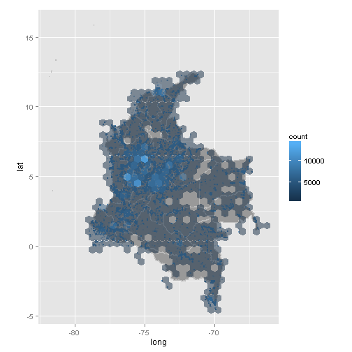

```r
map2
```

## The third map by institution

A map showing all the points. Colors by institution.

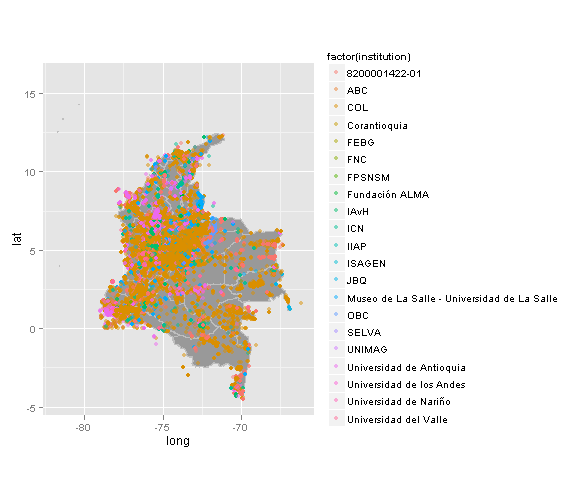

```r
map3
```

## The last map wraped by institution

This is slow, but worth…. meanwhile take a coffee.

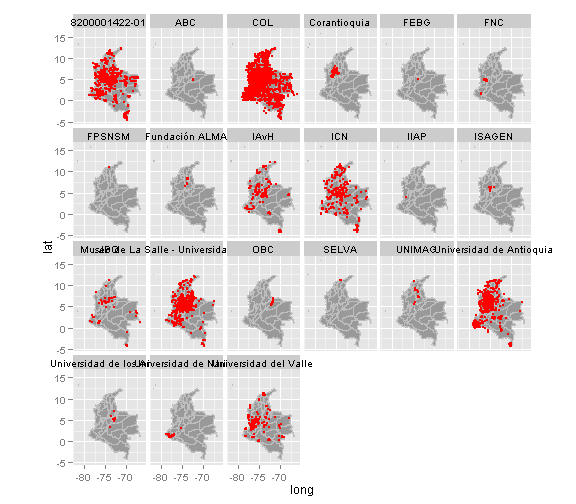

```r
map4
```

### It is nice to see how the Herbario Nacional Colombiano (COL) is the most extensive collection in Colombia. Now I have to figure which colection or institution is 8200001422-01.

After some coments from [@OigaMen](https://twitter.com/OigaMen) and [@Danipilze](https://twitter.com/Danipilze) the code 8200001422-01 is part of the IAvH collection. So for the next post I am going to fix that.

I had fun learning how to publish blog posts [from R + knitr to WordPress](http://yihui.name/knitr/demo/wordpress/). Next posts will even more interesting, I am sure.